# SUPERAR - reanalysis of meta-analyses on the effect of music education

Ivan Ropovik

2023-12-14

```r
knitr::opts_chunk$set(echo = FALSE, warning = FALSE)
```

**This is the supplementary analytic output for the reanalysis of meta-analyses on the effect of music education, carried out for the SUPERAR project**

**Brief information about the methods used in the analysis:**

**RMA results with model-based SEs** k = number of studies; sqrt in “Variance components” = tau, the standard deviation of true effects; estimate in “Model results” = naive MA estimate

**RVE SEs with Satterthwaite small-sample correction** Estimate based on a multilevel RE model with constant sampling correlation model (CHE - correlated hierarchical effects - working model) (Pustejovsky & Tipton, 2020; https://osf.io/preprints/metaarxiv/vyfcj/). Interpretation of naive-meta-analysis should be based on these estimates.

**Prediction interval** Shows the expected range of true effects in similar studies. As an approximation, in 95% of cases the true effect in a new *published* study can be expected to fall between PI LB and PI UB. Note that these are non-adjusted estimates. An unbiased newly conducted study will more likely fall in an interval centered around bias-adjusted estimate with a wider CI width.

**Heterogeneity** Tau can be interpreted as the total amount of heterogeneity in the true effects. I^2$ represents the ratio of true heterogeneity to total variance across the observed effect estimates. Estimates calculated by two approaches are reported. This is followed by separate estimates of between- and within-cluster heterogeneity and estimated intra-class correlation of underlying true effects.

**Proportion of significant results** What proportion of effects were statistically at the alpha level of .05.

**ES-precision correlation** Kendalls’s correlation between the ES and precision.

**4/3PSM** Applies a permutation-based, step-function 4-parameter selection model (one-tailed p-value steps = c(.025, .5, 1)). Falls back to 3-parameter selection model if at least one of the three p-value intervals contains less than 5 p-values. For this meta-analysis, we applied 3-parameter selection model by default as there were only 11 independent effects in the opposite direction overall (6%), causing the estimates to be unstable across iterations. pvalue = p-value testing H0 that the effect is zero. ciLB and ciUB are lower and upper bound of the CI. k = number of studies. steps = 3 means that the 4PSM was applied, 2 means that the 3PSM was applied. We also ran two sensitivity analyses of the selection model, the Vevea & Woods (2005) step function model with a priori defined selection weights and the Robust Bayesian Meta-analysis model employing the model-averaging approach (Bartoš & Maier, 2020).

**PET-PEESE** Estimated effect size of an infinitely precise study. Using 4/3PSM as the conditional estimator instead of PET (can be changed to PET). If the PET-PEESE estimate is in the opposite direction, the effect can be regarded nil. By default (can be changed to PET), the function employs a modified sample-size based estimator (see https://www.jepusto.com/pet-peese-performance/). It also uses the same RVE sandwich-type based estimator in a CHE (correlated hierarchical effects) working model with the identical random effects structure as the primary (naive) meta-analytic model.

We report results for both, PET and PEESE, with the first reported one being the primary (based on the conditional estimator).

**WAAP-WLS** The combined WAAP-WLS estimator (weighted average of the adequately powered - weighted least squares) tries to identify studies that are adequately powered to detect the meta-analytic effect. If there is less than two such studies, the method falls back to the WLS estimator (Stanley & Doucouliagos, 2015). If there are at least two adequately powered studies, WAAP returns a WLS estimate based on effects from only those studies.

type = 1: WAAP estimate, 2: WLS estimate. kAdequate = number of adequately powered studies

**p-uniform** P-uniform* is a selection model conceptually similar to p-curve. It makes use of the fact that p-values follow a uniform distribution at the true effect size while it includes also nonsignificant effect sizes. Permutation-based version of p-uniform method, the so-called p-uniform* (van Aert, van Assen, 2021).

**p-curve** Permutation-based p-curve method. Output should be self-explanatory. For more info see p-curve.com

**Power for detecting SESOI and bias-corrected parameter estimates** Estimates of the statistical power for detecting a smallest effect sizes of interest equal to .20, .50, and .70 in SD units (Cohen’s d). A sort of a thought experiment, we also assumed that population true values equal the bias-corrected estimates (4/3PSM or PET-PEESE) and computed power for those.

**Handling of dependencies in bias-correction methods** To handle dependencies among the effects, the 4PSM, p-curve, p-uniform are implemented using a permutation-based procedure, randomly selecting only one focal effect (i.e., excluding those which were not coded as being focal) from a single study and iterating nIterations times. Lastly, the procedure selects the result with the median value of the ES estimate (4PSM, p-uniform) or median z-score of the full p-curve (p-curve).

# Results

```
## $gordon
## $gordon$phonologicalAwareness
## $gordon$phonologicalAwareness$resultsOverall
## $gordon$phonologicalAwareness$resultsOverall$`RMA results with model-based SEs`
##
## Multivariate Meta-Analysis Model (k = 18; method: REML)
##
## Variance Components:
##
##             estim    sqrt  nlvls  fixed            factor
## sigma^2.1  0.0000  0.0000     11     no           paperID
## sigma^2.2  0.0699  0.2643     18     no  paperID/effectID
##
## Test for Heterogeneity:
## Q(df = 17) = 36.1512, p-val = 0.0044
##
## Model Results:
##
## estimate      se    zval    pval   ci.lb   ci.ub
##   0.2177  0.1015  2.1447  0.0320  0.0187  0.4166  *
##
## ---
## Signif. codes:  0 '***' 0.001 '**' 0.01 '*' 0.05 '.' 0.1 ' ' 1
##
##
## $gordon$phonologicalAwareness$resultsOverall$`RVE SEs with Satterthwaite small-sample correction`
## $gordon$phonologicalAwareness$resultsOverall$`RVE SEs with Satterthwaite small-sample correction`$test
##    Coef. Estimate     SE t-stat d.f. (Satt) p-val (Satt) Sig.
##  intrcpt    0.218 0.0934   2.33        8.27       0.0472    *
##
## $gordon$phonologicalAwareness$resultsOverall$`RVE SEs with Satterthwaite small-sample correction`$CIs
##    Coef. Estimate     SE d.f. Lower 95% CI Upper 95% CI
##  intrcpt    0.218 0.0934 8.27      0.00344        0.432
##
##
## $gordon$phonologicalAwareness$resultsOverall$`Prediction interval`
## 95% PI LB 95% PI UB
##    -0.405     0.840
##
## $gordon$phonologicalAwareness$resultsOverall$Heterogeneity
```

[output cut: 910 more lines]

```
##  Within-cluster heterogeneity                           ICC
##                    3.72000000                    0.50000000
##
## $ye$aggressionPropensity$resultsOverall$`Proportion of significant results`
## [1] NA
##
## $ye$aggressionPropensity$resultsOverall$`Publication bias`
## [1] "Publication bias corrections not carried out"
##
##
## $ye$aggressionPropensity$resultsTable
##                  k         g [95% CI]    95% PI [LB, UB]                 SE
##                  2 -0.03 [-0.9, 0.85]    [-0.865, 0.811]               0.07
##                Tau                I^2
##               0.06                 7%
```

# Funnel plots

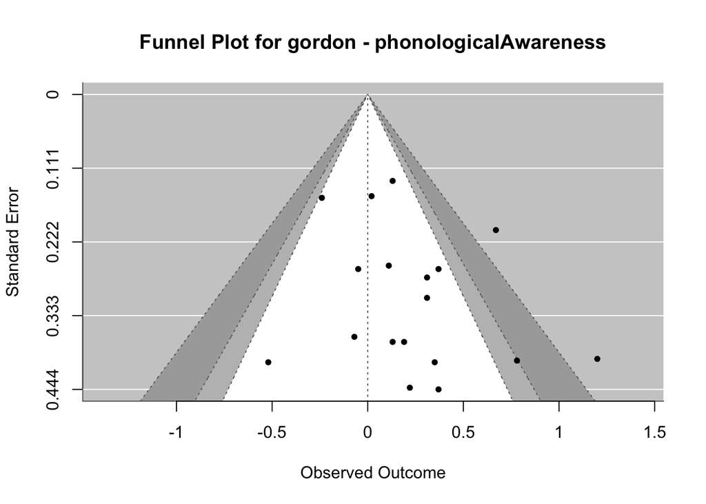

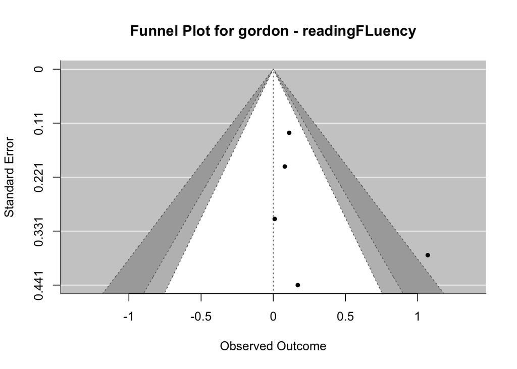

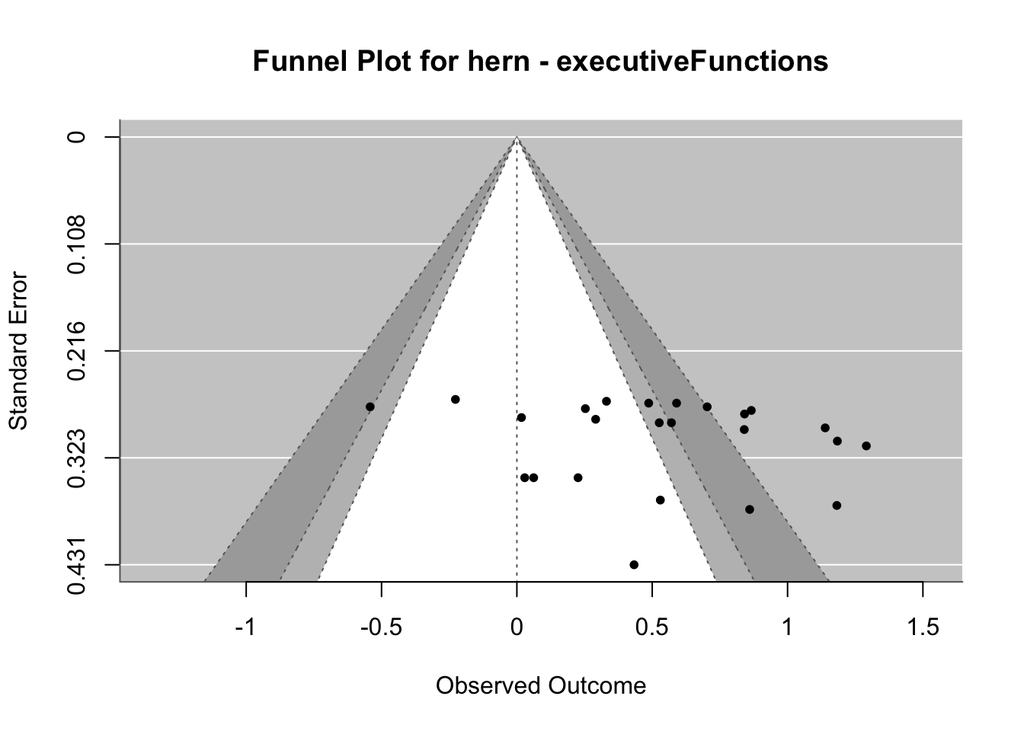

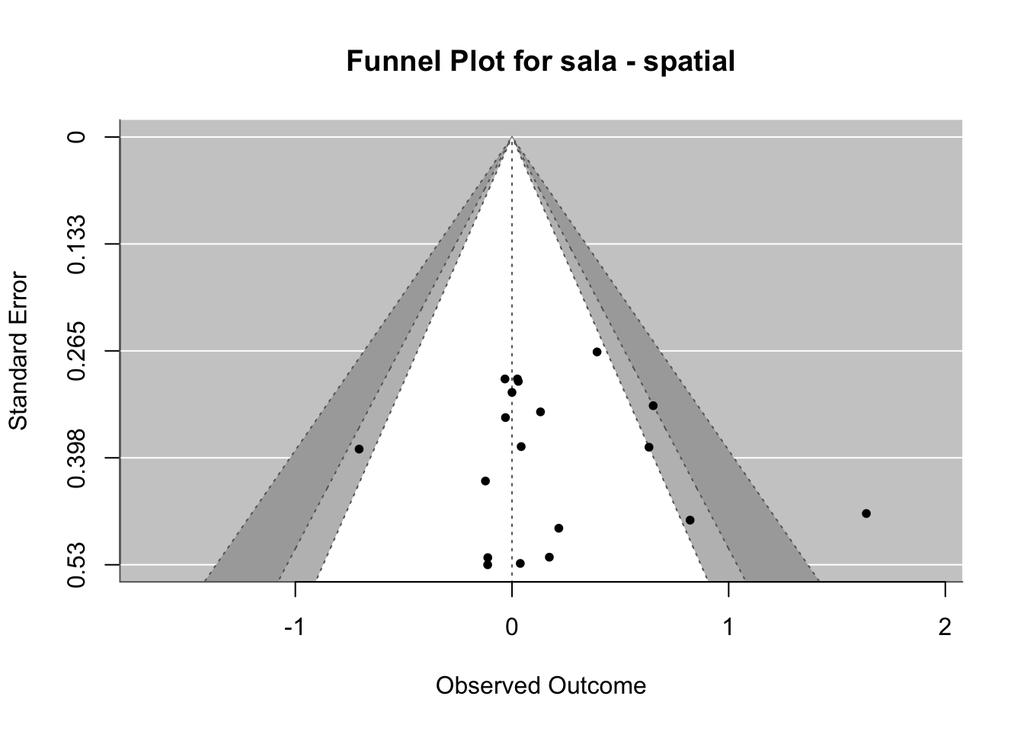

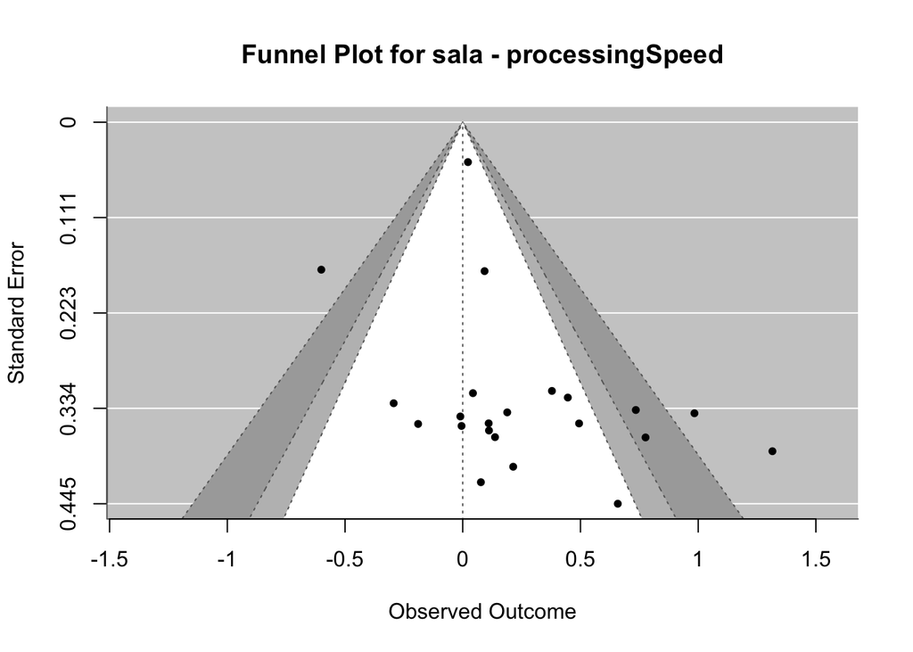

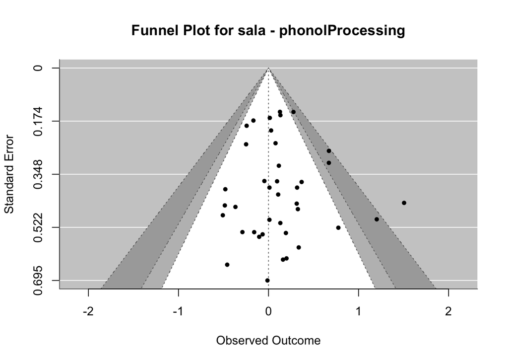

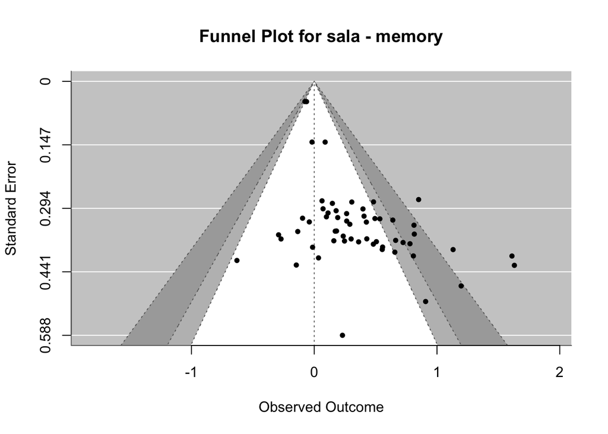

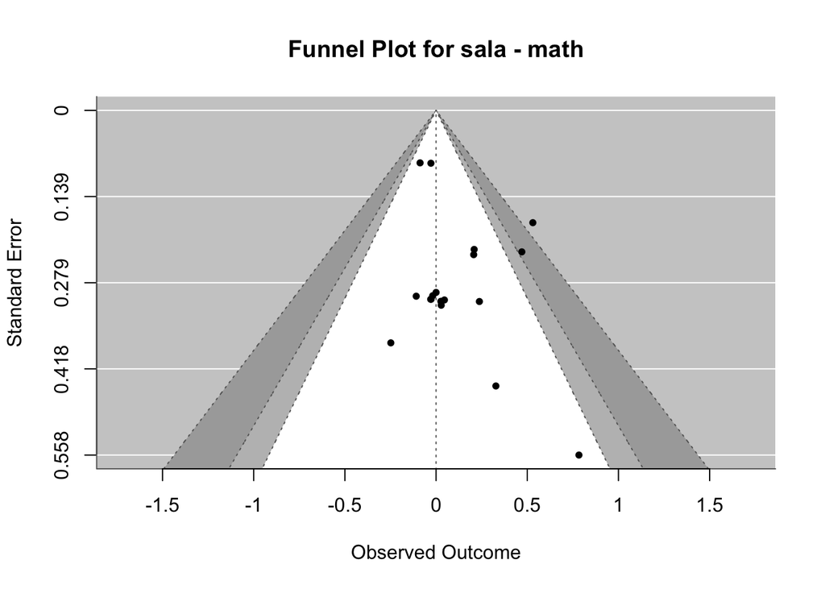

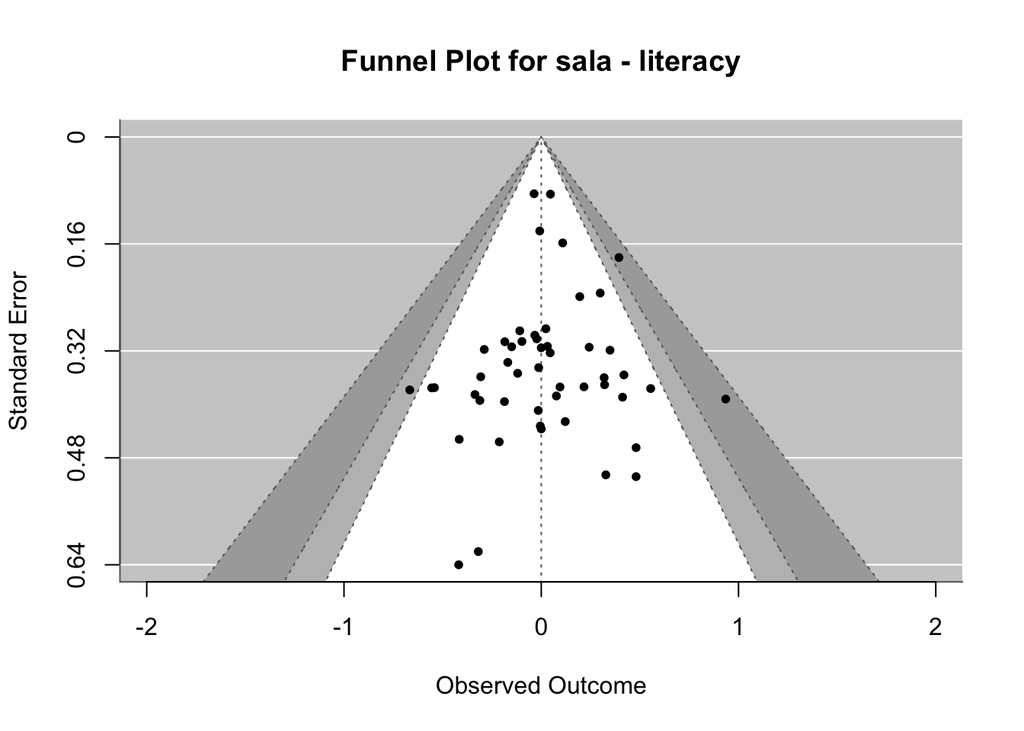

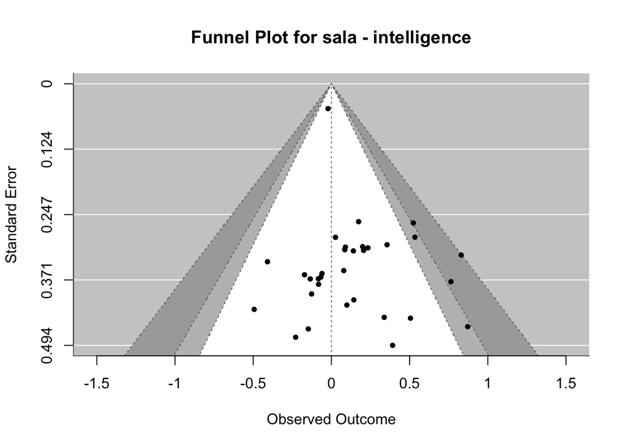

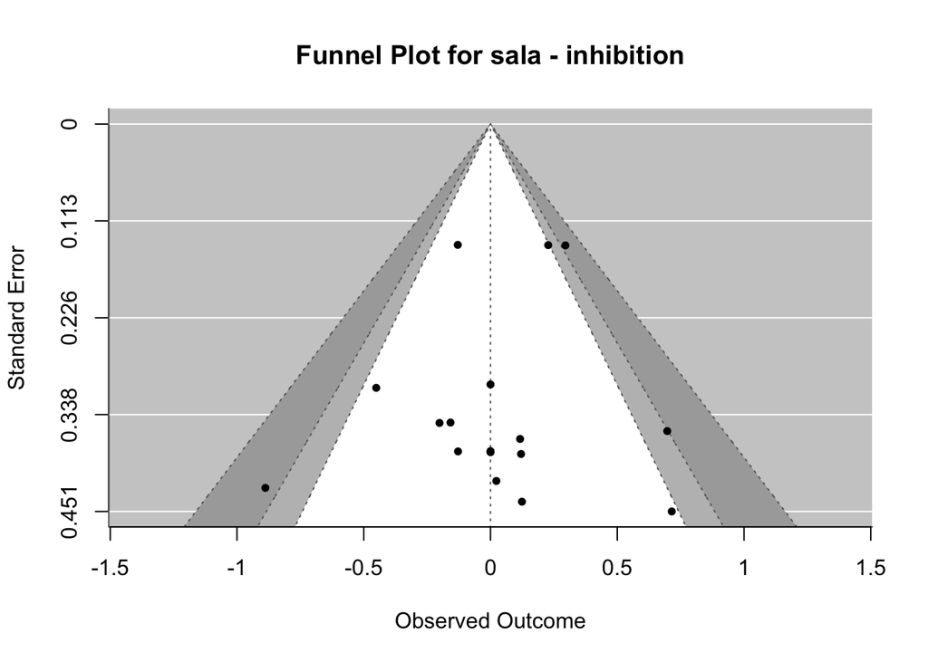

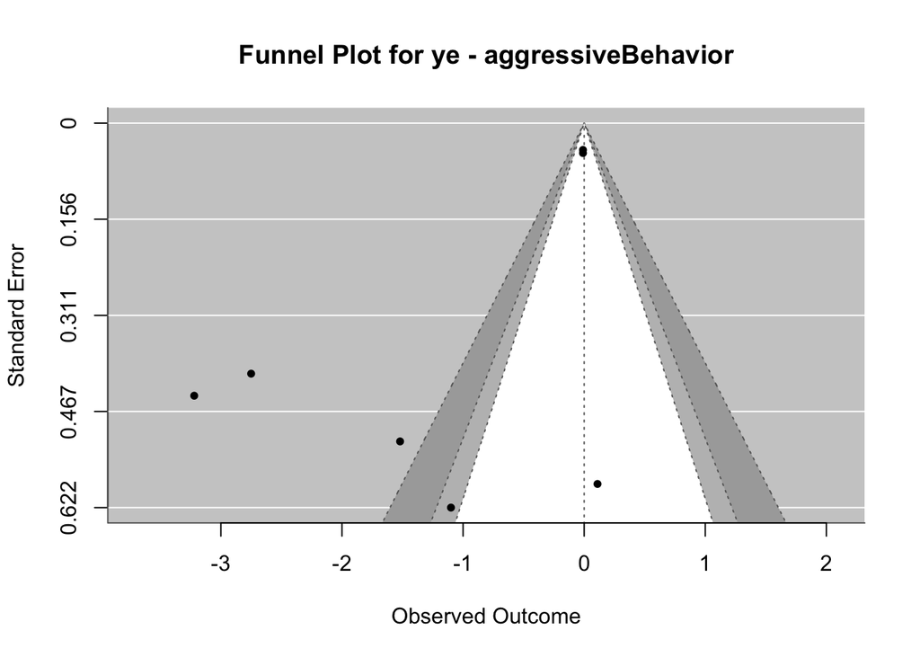

[4 more figures not shown]

[output not shown]

[output cut: 364 more lines]